# Modeling Data in the Tidyverse Course Project

Oswaldo Navarrete

2023-09-16

## Loading packages

```r
library(tidyverse)
library(tidymodels)
library(tm)
library(wordcloud)
library(doParallel)
library(vip)
library(skimr)
library(jtools)
```

## Use multiple cores in order to improve run time

```r
detectCores()
```

```
## [1] 20
```

```r
doParallel::registerDoParallel(cores=8)
```

## Loading data and checking the data structure

The training and the testing dataset have 6 variables, the most important variables in the training set are Product and Consumer.complaint.narrative. In the testing set the only variable to be used is Consumer.complaint.narrative. In the two datasets, the Consumer.complaint.narrative doesn’t have NAs. This variable was renamed in both datasets as Complaint, also in the training data the variable product was converted to factor.

```r
training <- read.csv("data_complaints_train.csv")
testing <- read.csv("data_complaints_test.csv")

names(training)
```

```
## [1] "Product"                      "Consumer.complaint.narrative"
## [3] "Company"                      "State"
## [5] "ZIP.code"                     "Submitted.via"
```

```r
names(testing)
```

```
## [1] "problem_id"                   "Consumer.complaint.narrative"
## [3] "Company"                      "State"
## [5] "ZIP.code"                     "Submitted.via"
```

```r
skim(training)
```

Data summary

| Name | training |
| --- | --- |
| Number of rows | 90975 |
| Number of columns | 6 |
| _______________________ |  |
| Column type frequency: |  |
| character | 6 |
| ________________________ |  |
| Group variables | None |

**Variable type: character**

| skim_variable | n_missing | complete_rate | min | max | empty | n_unique | whitespace |
| --- | --- | --- | --- | --- | --- | --- | --- |
| Product | 0 | 1 | 8 | 27 | 0 | 4 | 0 |
| Consumer.complaint.narrative | 0 | 1 | 12 | 32317 | 0 | 90240 | 0 |
| Company | 0 | 1 | 4 | 82 | 0 | 1497 | 0 |
| State | 0 | 1 | 2 | 36 | 0 | 62 | 0 |
| ZIP.code | 0 | 1 | 4 | 5 | 0 | 5484 | 0 |
| Submitted.via | 0 | 1 | 3 | 3 | 0 | 1 | 0 |

```r
skim(testing)
```

Data summary

| Name | testing |
| --- | --- |
| Number of rows | 20 |
| Number of columns | 6 |
| _______________________ |  |
| Column type frequency: |  |
| character | 5 |
| numeric | 1 |
| ________________________ |  |
| Group variables | None |

**Variable type: character**

| skim_variable | n_missing | complete_rate | min | max | empty | n_unique | whitespace |
| --- | --- | --- | --- | --- | --- | --- | --- |
| Consumer.complaint.narrative | 0 | 1 | 338 | 11872 | 0 | 20 | 0 |
| Company | 0 | 1 | 12 | 41 | 0 | 16 | 0 |
| State | 0 | 1 | 2 | 2 | 0 | 13 | 0 |
| ZIP.code | 0 | 1 | 4 | 5 | 0 | 15 | 0 |
| Submitted.via | 0 | 1 | 3 | 3 | 0 | 1 | 0 |

**Variable type: numeric**

| skim_variable | n_missing | complete_rate | mean | sd | p0 | p25 | p50 | p75 | p100 | hist |
| --- | --- | --- | --- | --- | --- | --- | --- | --- | --- | --- |
| problem_id | 0 | 1 | 10.5 | 5.92 | 1 | 5.75 | 10.5 | 15.25 | 20 | ▇▇▇▇▇ |

```r
training <- training |>
  rename(Complaint = Consumer.complaint.narrative) |>
  select(Product, Complaint) |>
  mutate(Product = factor(Product))

testing <- testing |>
  rename(Complaint = Consumer.complaint.narrative) |>
  select(Complaint)
```

## Cleaning and preparing the training and testing data sets.

For the two datasets, it’s important prepare the Consumer.complaint.narrative because this variable is a long narrative.

### Training

The first step involved the following processes:

1. The private information has been masked as “XX”, “XXX” and “XXXX”, these character strings were removed.
2. All the letters were converted to lower case.
3. The numbers were removed.
4. Punctuation was removed.
5. Special characters and white spaces are removed.
6. The stop words were removed

```r
training_clean <- training |>
  mutate(Complaint = gsub("[XX]+", "", Complaint)) |>
  mutate(Complaint = str_to_lower(Complaint)) |>
  mutate(Complaint = gsub("[0-9]", "", Complaint)) |>
  mutate(Complaint = removePunctuation(Complaint)) |>
  mutate(Complaint = gsub("\n", "", Complaint)) |>
  mutate(Complaint = gsub("\t", "", Complaint)) |>
  mutate(Complaint = stripWhitespace(Complaint))

training_complaints <- Corpus(VectorSource(training_clean$Complaint)) |>
  tm_map(removeWords, stopwords())
```

A document term matrix was created, each complaint is a document in a row and each column is a term of the document. The value of each cell belongs to the number of times the term appears in the document.

```r
training_docterm <- DocumentTermMatrix(training_complaints)
inspect(training_docterm)
```

```
## <<DocumentTermMatrix (documents: 90975, terms: 81664)>>
## Non-/sparse entries: 7048324/7422334076
## Sparsity           : 100%
## Maximal term length: 2229
## Weighting          : term frequency (tf)
## Sample             :
##        Terms
## Docs    account bank card credit loan mortgage payment payments received told
##   19650       4   34    0      3   49       10       6        7       12    0
##   25455      79    2    0     11   80       57      29        4        3    0
##   27671       2    1    0      1    4        4       8        5        1    0
##   33614       2   32    2      6    1       12       1        0        3    0
##   64243       0    0    0      0   26       15       1       10        4    2
##   68621       9    0    0     10   56        0      16        9       10    8
##   70389       1    0    0      3    2       26       0        3        0    0
##   73540       8    1    0      6   33       61       7       37        3    0
##   77518       0    0    0      0  103        0      45        1        0    2
##   84551      36    0    0      8   68       60      22       16        0    0
```

The dataset had 81664 terms, so it’s convenient to reduce the number of terms. I decided to choose the terms that occur at least 1500 times, this threshold is arbitrary but helps to reduce the number of terms.

```r
limitfreq <- findFreqTerms(training_docterm, lowfreq=1500)
training_docterm <- DocumentTermMatrix(training_complaints,
                                       list(dictionary=limitfreq))
inspect(training_docterm)
```

```
## <<DocumentTermMatrix (documents: 90975, terms: 1155)>>
## Non-/sparse entries: 5328948/99747177
## Sparsity           : 95%
## Maximal term length: 15
## Weighting          : term frequency (tf)
## Sample             :
##        Terms
## Docs    account bank card credit loan mortgage payment payments received told
##   11002       1    5    0      1   68       42       4        4       10    1
##   11343       4    0    1      9   30        6       7        1        2   57
##   19650       4   34    0      3   49       10       6        7       12    0
##   25436      67    6    0      9   86       61      25        3        5    0
##   25455      79    2    0     11   80       57      29        4        3    0
##   60769       0    0    6      5   43        6       7        4       27   18
##   64243       0    0    0      0   26       15       1       10        4    2
##   68621       9    0    0     10   56        0      16        9       10    8
##   73540       8    1    0      6   33       61       7       37        3    0
##   84551      36    0    0      8   68       60      22       16        0    0
```

Now, the number of terms decreased to 1155. The sparsity fell down to 95%. The following step is remove the terms with a 95% minimum of sparsity.

```r
training_docterm <- removeSparseTerms(training_docterm, 0.95)
inspect(training_docterm)
```

```
## <<DocumentTermMatrix (documents: 90975, terms: 341)>>
## Non-/sparse entries: 3548303/27474172
## Sparsity           : 89%
## Maximal term length: 14
## Weighting          : term frequency (tf)
## Sample             :
##        Terms
## Docs    account bank card credit loan mortgage payment payments received told
##   11002       1    5    0      1   68       42       4        4       10    1
##   11343       4    0    1      9   30        6       7        1        2   57
##   25455      79    2    0     11   80       57      29        4        3    0
##   37990      12    6    0     11   41        6       6        4       29    9
##   56802      18    7    0      0    6       20      17       17       21    8
##   60769       0    0    6      5   43        6       7        4       27   18
##   64243       0    0    0      0   26       15       1       10        4    2
##   68621       9    0    0     10   56        0      16        9       10    8
##   70174       8    1    0      7   41        5      59       32        5    9
##   84551      36    0    0      8   68       60      22       16        0    0
```

The sparsity has reduced to 89% with 341 terms, before starting is a good idea explore the terms in order to determine if exist irrelevant or unnecessary terms.

```r
training_docterm_df <- training_docterm |>
  as.matrix() |>
  as.data.frame()
```

Looking at the terms it’s possible realize that there are unnecessary terms so the following step is rebuild the docterm matrix removing previously the “unnecessary” terms and adding the other filters applied before.

```r
training_docterm_df  |>
  summarise_all(sum)
```

```
##   account almost amount anything  bank  card  case charge charged charges chase
## 1  117566   5776  44617    10846 63024 93671 13613  22745   16573   22001 22237
##   closed didnt  even feel fraud getting however immediately interest  last
## 1  19003 15843 28717 8670 16792   10002   17066       10500    42043 17183
##    late later letter  make  many months never   new original   pay  sent
## 1 39253 13587  39799 34029 11237  29746 47774 29102    10105 51811 42548
##   statement stating still   use  will   yet  ago  also asked  back cant
## 1     23808   14308 31371 12255 48615 10791 7565 39453 32690 50662 8120
##   complaint contact contacted credit  debt dispute  done   due ever fact
## 1     20936   18009     21563 123231 12707   18296 12792 49787 7016 9456
##   financial first form given going   got happened  home income  just mortgage
## 1     17501 22992 7309 11354 17662 17168     7480 36074  12115 24582    73598
##   note   now   one order  owe  past period point receive received refused
## 1 8433 40050 52298 11333 7243 13001   8000 10274   16982    67255    9818
##   removed report request requesting  send something spoke stated submitted
## 1    7494  22450   22511       5989 17233      6414 18875  21656     11190
##    time  told unable using  want   way  went working  year years   can gave
## 1 62293 76344   7972  7876 17745 12862 16675    7350 18740 26660 45510 8501
##     get information  like loans making much   put since student transferred
## 1 48903       42565 19369 25575  12550 8084 14307 35532   12437        9687
##   business service federal including instead review second  take another  fees
## 1    15295   28081    8886      5939    7655   9557   8339 17853   22681 21947
##    full good  keep  made  mail online  paid payment purchase score system
## 1 16627 9182 10043 48526 13452  16342 44542  125209    13373  9961   9236
##   thought   via  work answer applied  ask  call called check   fee  help  need
## 1    5435 10736 15917   6953   18354 8974 44637  61445 25024 20596 25725 20144
##   previous problem provided representative response started three calls company
## 1     6939   11207    15652          18064    13969    8372  9305 13459   51569
##    days   end hours payments phone agreement asking   loan office paperwork
## 1 34912 10976  8062    73240 33049      9338   8425 116300   9237      8033
##   paying regarding   see statements understand wanted advised around balance
## 1  15769     10704 20663      10292       6860   7794   11032   9053   38122
##    find money monthly  rep reporting returned website week assistance complete
## 1 10562 31006   19358 8170      9641     8704    9817 8686       7113     6379
##   department documents  dont every issue  may modification month number please
## 1      16811     18996 15634 15593 21151 8815        18528 33346  27604  18504
##   process stop funds  give  know matter provide  say thank times transaction
## 1   19818 6026 12701 11413 19565   9644   14519 7933  6789 21883        9144
##   believe currently  next program services several address calling claim filed
## 1   11253      5608 10714   10253     9417   16876   14138    6673 11761 10573
```

[output cut: 11 more lines]

```
## 1     9092 6623 11847  10236 14520 5990       15063  7469     5686  13419 10972
##   situation always customer long multiple saying terms weeks attached available
## 1     10790   7065    26921 6177     9332   9752  7838  9843    10188      6909
##   denied email error  set  well closing sold tell escrow  took attorney   ive
## 1  10316 27621  9248 8607 14718   12577 7723 8570  19747 12551     8808 10626
##   resolved reported state states  file must though   two different longer
## 1     6290     9607  8618   7029 11814 6417   9440 21099     11160   6722
##   receiving sure accounts consumer documentation nothing  per return cards
## 1      6252 8177    10929     9928          9637   13225 9420   8097 10511
##    able finally line notice signed explained proof approved offer supervisor
## 1 16662    9020 8760  11618   9616     10039  9568     9432 11352      11661
##   trying wasnt agreed copy issues prior within right history show transfer look
## 1  13927  5746   7702 9420   7845  8032  11148  9951    7471 6391     9804 5555
##   purchased care left person owed manager speak showing
## 1      7634 6929 7495  10491 6855    9716  9621    7407
```

```r
list_terms <- sort(names(training_docterm_df))

unnecessary_terms <- c("able","ago","already","also","another",
                       "anything","asked","back","believe",
                       "call","called","calling","can","didnt",
                       "done","dont","either","even","get",
                       "going","got","however","just",
                       "later","like","needed","never","now",
                       "please","put","said","said","saying",
                       "take","today","told","took","used",
                       "want","way","went","will","without")
```

```r
training_complaints<-tm_map(training_complaints, removeWords, unnecessary_terms)
training_docterm <- DocumentTermMatrix(training_complaints,
                                       list(dictionary=limitfreq))

training_docterm <- removeSparseTerms(training_docterm, 0.95)
inspect(training_docterm)
```

```
## <<DocumentTermMatrix (documents: 90975, terms: 299)>>
## Non-/sparse entries: 2890265/24311260
## Sparsity           : 89%
## Maximal term length: 14
## Weighting          : term frequency (tf)
## Sample             :
##        Terms
## Docs    account bank card credit loan mortgage payment payments received time
##   11002       1    5    0      1   68       42       4        4       10   10
##   15879       2   73    0      0   19       12       2        6       38    6
##   19650       4   34    0      3   49       10       6        7       12    5
##   25436      67    6    0      9   86       61      25        3        5    2
##   25455      79    2    0     11   80       57      29        4        3    3
##   56802      18    7    0      0    6       20      17       17       21   12
##   60769       0    0    6      5   43        6       7        4       27    9
##   64243       0    0    0      0   26       15       1       10        4   20
##   68621       9    0    0     10   56        0      16        9       10   15
##   84551      36    0    0      8   68       60      22       16        0    8
```

```r
training_docterm_df <- training_docterm |>
  as.matrix() |>
  as.data.frame()

dim(training_docterm_df)
```

```
## [1] 90975   299
```

Finally, the training dataset is combined with the product’s information of the training_clean dataset made at the beginning.

```r
training_docterm_df <- training_docterm_df |>
  bind_cols(Product=training_clean$Product) |>
  select(Product, everything())
```

### Testing

For the testing set, only the steps that involve the cleaning, and get the docterm matrix with the frequent terms were made.

```r
testing_clean <- testing |>
  mutate(Complaint = gsub("[XX]+", "", Complaint)) |>
  mutate(Complaint = str_to_lower(Complaint)) |>
  mutate(Complaint = gsub("[0-9]", "", Complaint)) |>
  mutate(Complaint = removePunctuation(Complaint)) |>
  mutate(Complaint = gsub("\n", "", Complaint)) |>
  mutate(Complaint = gsub("\t", "", Complaint)) |>
  mutate(Complaint = stripWhitespace(Complaint))

testing_complaints <- Corpus(VectorSource(testing_clean$Complaint)) |>
  tm_map(removeWords, stopwords())
testing_docterm <- DocumentTermMatrix(testing_complaints, list(dictionary=limitfreq))

testing_df <- testing_docterm |>
  as.matrix() |>
  as.data.frame()
```

## Building a ML model for predicting the product’s category

### Train and validation sets

The training_docterm_df was splitted to train (75%) and validate (25%) the model.

```r
set.seed(1110)
training_df_split <- rsample::initial_split(data = training_docterm_df, prop = 3/4)
train_df <- training(training_df_split)
valid_df <- testing(training_df_split)
```

### Cross validation folds

A 10-fold cross validation was created.

```r
vfold_df <- rsample::vfold_cv(data = train_df, v = 10)
vfold_df
```

```
## #  10-fold cross-validation
## # A tibble: 10 × 2
##    splits               id
##    <list>               <chr>
##  1 <split [61407/6824]> Fold01
##  2 <split [61408/6823]> Fold02
##  3 <split [61408/6823]> Fold03
##  4 <split [61408/6823]> Fold04
##  5 <split [61408/6823]> Fold05
##  6 <split [61408/6823]> Fold06
##  7 <split [61408/6823]> Fold07
##  8 <split [61408/6823]> Fold08
##  9 <split [61408/6823]> Fold09
## 10 <split [61408/6823]> Fold10
```

### Machine learning workflow

#### Recipe

```r
train_df_rec <- train_df |>
  recipe(Product ~ .) |>
  step_corr(all_predictors()) |>
  step_nzv(all_predictors())
```

#### Model

```r
train_df_model <- rand_forest(mtry = 10, min_n = 4) |>
  set_engine("randomForest") |>
  set_mode("classification")
```

#### Workflow

```r
train_df_wflow <- workflow() |>
  add_recipe(train_df_rec) |>
  add_model(train_df_model)
```

### Fit and model performance

After setting the recipe, model, and workflow the workflow was fitted. With the fitted model, the importance of the variables was analyzed. According to the importance plot, the most important words for the prediction were: mortgage, card and loan.

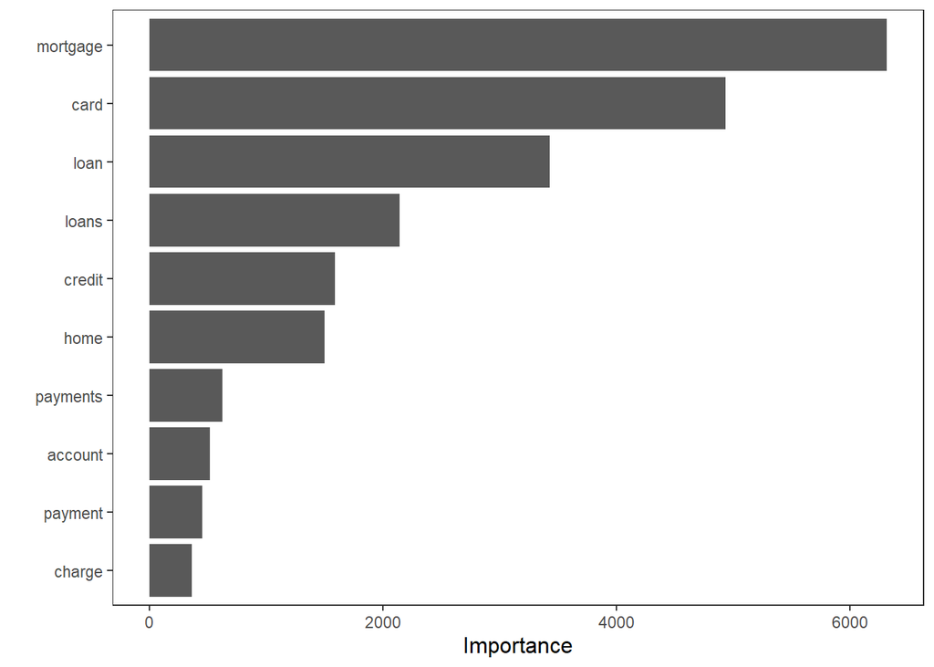

```r
train_df_fit <- fit(train_df_wflow, data = train_df)

train_df_wflow_fit <- train_df_fit |>
  extract_fit_parsnip()|>
  vip(num_features = 10) +
  theme_apa()

train_df_wflow_fit
```

#### Fitting to resamples

Using cross validation, the model performance was evaluated.

```r
set.seed(1110)

resample_train_df_fit <- tune::fit_resamples(train_df_wflow,
                                             vfold_df,
                                             control = control_resamples(save_pred = TRUE))

collect_metrics(resample_train_df_fit)
```

```
## # A tibble: 2 × 6
##   .metric  .estimator  mean     n  std_err .config
##   <chr>    <chr>      <dbl> <int>    <dbl> <chr>
## 1 accuracy multiclass 0.844    10 0.00127  Preprocessor1_Model1
## 2 roc_auc  hand_till  0.937    10 0.000833 Preprocessor1_Model1
```

The values of the accuracy and the ROC AUC were $84.39 \%$ and $0.9368$ respectively.

### Model tuning

Although the metrics are good, a model tuning was probed.

```r
tune_RF_model <- rand_forest(mtry = tune(), min_n = tune()) |>
  set_engine("randomForest") |>
  set_mode("classification")
```

```r
RF_tune_wflow <- workflows::workflow() |>
  workflows::add_recipe(train_df_rec) |>
  workflows::add_model(tune_RF_model)
```

```r
doParallel::registerDoParallel(cores=8)

set.seed(1110)

tune_RF_results <- tune_grid(object = RF_tune_wflow, resamples = vfold_df, grid = 20 )
```

```
## i Creating pre-processing data to finalize unknown parameter: mtry
```

### Performance

```r
show_best(tune_RF_results, metric="accuracy")
```

```
## # A tibble: 5 × 8
##    mtry min_n .metric  .estimator  mean     n std_err .config
##   <int> <int> <chr>    <chr>      <dbl> <int>   <dbl> <chr>
## 1    28     4 accuracy multiclass 0.854    10 0.00104 Preprocessor1_Model13
## 2    35     9 accuracy multiclass 0.854    10 0.00126 Preprocessor1_Model15
## 3    73    13 accuracy multiclass 0.852    10 0.00132 Preprocessor1_Model11
## 4    48    31 accuracy multiclass 0.851    10 0.00128 Preprocessor1_Model19
## 5    55    36 accuracy multiclass 0.851    10 0.00134 Preprocessor1_Model10
```

The accuracy raised up to $85.41\%$, with the best model the workflow was updated.

```r
tuned_values<-select_best(tune_RF_results,"accuracy")
RF_tuned_wflow <- RF_tune_wflow |>
  finalize_workflow(tuned_values)
```

## Final Model Performance Evaluation

```r
overall_fit<-last_fit(RF_tuned_wflow, training_df_split)
collect_metrics(overall_fit)
```

```
## # A tibble: 2 × 4
##   .metric  .estimator .estimate .config
##   <chr>    <chr>          <dbl> <chr>
## 1 accuracy multiclass     0.851 Preprocessor1_Model1
## 2 roc_auc  hand_till      0.939 Preprocessor1_Model1
```

```r
test_predictions<-collect_predictions(overall_fit)
head(test_predictions)
```

```
## # A tibble: 6 × 9
##   id               .pred_Credit card or pr…¹ .pred_Mortgage `.pred_Student loan`
##   <chr>                                <dbl>          <dbl>                <dbl>
## 1 train/test split                     0.982          0.012                0.004
## 2 train/test split                     0.562          0.054                0.088
## 3 train/test split                     0.032          0.344                0.138
## 4 train/test split                     0.558          0.064                0.14
## 5 train/test split                     0.984          0.002                0.002
## 6 train/test split                     1              0                    0
## # ℹ abbreviated name: ¹`.pred_Credit card or prepaid card`
## # ℹ 5 more variables: `.pred_Vehicle loan or lease` <dbl>, .row <int>,
## #   .pred_class <fct>, Product <fct>, .config <chr>
```

### Prediction’s visualization

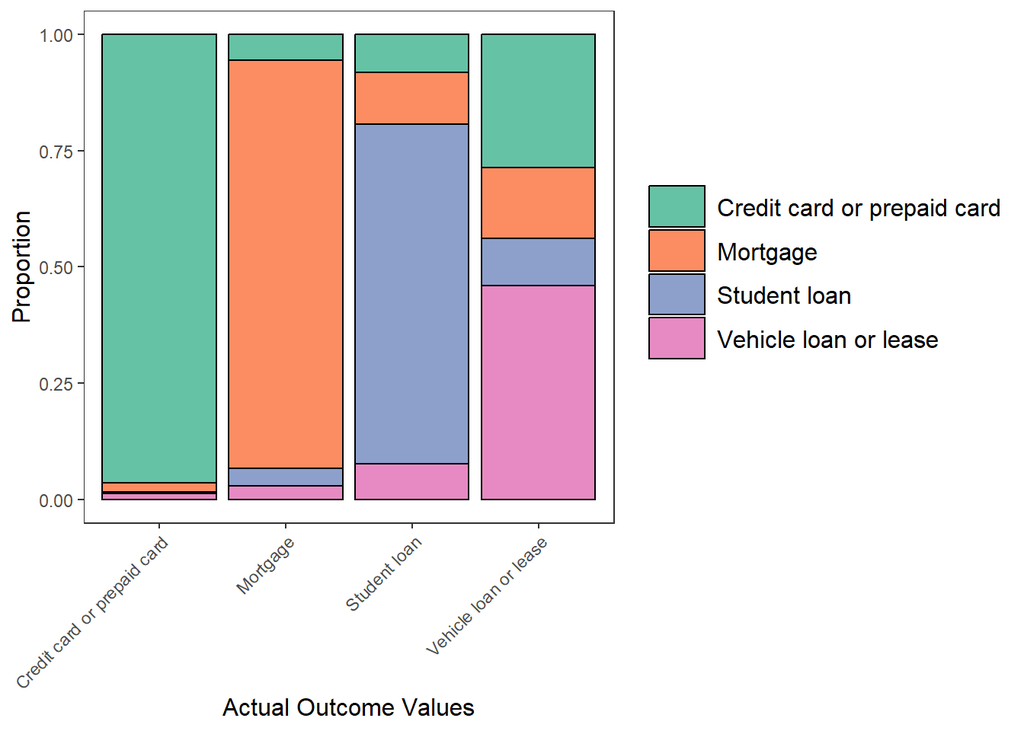

```r
ggplot(test_predictions, aes(x=Product, fill=.pred_class)) +
     geom_bar(position="fill", color="black") +
     scale_fill_brewer(palette="Set2") + labs(x="Actual Outcome Values",
     y="Proportion", fill="Predicted Outcome") +
     theme_apa() +
     theme(axis.text.x=element_text(angle=45, hjust=1, vjust=1))
```

The model works well for all the categories except for *Vehicle loan or lease*.

## Prediction for the test data

Finally, the prediction is made for the test data provided in the instructions.

```r
final_model<-fit(RF_tuned_wflow, training_docterm_df)
predict(final_model, new_data=testing_df)
```

```
## # A tibble: 20 × 1
##    .pred_class
##    <fct>
##  1 Vehicle loan or lease
##  2 Mortgage
##  3 Vehicle loan or lease
##  4 Mortgage
##  5 Vehicle loan or lease
##  6 Credit card or prepaid card
##  7 Credit card or prepaid card
##  8 Credit card or prepaid card
##  9 Student loan
## 10 Vehicle loan or lease
## 11 Mortgage
## 12 Mortgage
## 13 Credit card or prepaid card
## 14 Credit card or prepaid card
## 15 Mortgage
## 16 Credit card or prepaid card
## 17 Mortgage
## 18 Student loan
## 19 Vehicle loan or lease
## 20 Vehicle loan or lease
```